# chapter6

Laura Jernstöm

12/2/2020

# CHAPTER 6

## Part 1.

Analysis of Chpater 8 of Kimmos’ book with rats data

Description of data:

“Data from a nutrition study conducted in three groups of rats (Crowder and Hand, 1990). The three groups were put on different diets, and each animal’s body weight (grams) was recorded repeatedly (approximately weekly, except in week seven when two recordings were taken) over a 9-week period.” (Vehkalahti and Everitt, ?)

Implement the analyses of Chapter 8 of MABS using the RATS data. (0-7 points: 0-4 points for graphs or analysis results + 0-3 points for their interpretations)

```r
rm(list=ls())

date()
```

```
## [1] "Thu Dec 03 13:30:57 2020"
```

```r
# Data
rats <- read.table("https://raw.githubusercontent.com/KimmoVehkalahti/MABS/master/Examples/data/rats.txt",
                   sep ="", header = TRUE)
ratsl <- read.table( "Z:/FDPE/Courses/Datamooc/IODS-project/data/ratsl.txt", sep = " ", header = TRUE)

names(ratsl)
```

```
## [1] "ID"    "Group" "Time"  "rats"
```

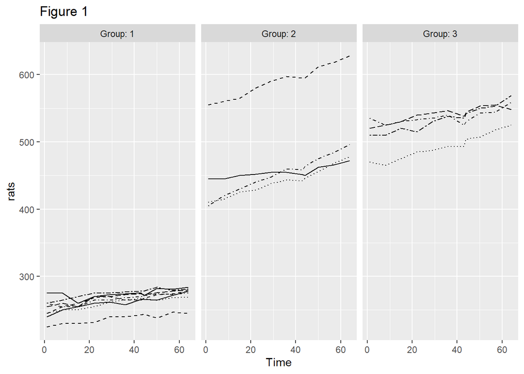

```r
#Access the package ggplot2
library(ggplot2)
library(tidyr)
library(dplyr)
ratsl$ID <- as.factor(ratsl$ID)
ratsl$Group <- as.factor(ratsl$Group)

# Draw the plot
ggplot(ratsl, aes(x = Time, y = rats, linetype = ID)) +
  geom_line() +
  scale_linetype_manual(values = rep(1:10, times=4)) +
  facet_grid(. ~ Group, labeller = label_both) +
  theme(legend.position = "none") +
  scale_y_continuous(limits = c(min(ratsl$rats), max(ratsl$rats))) + ggtitle("Figure 1")
```

All groups seam to have relatively similar slopes among individuals, with perhaps a small exception in Group 2, which speaks of tracking phenomenon i.e. individuals having high scores in the beginning tend to have them in the end as well.

Variability in the groups looks quite small with all groups having one possible outlier with Group 2 having one large outlier. Slopes are also increasing i.e. rats scores increase over time.

```r
# Standardise the variable rats
ratsl <- ratsl %>%
  group_by(Time) %>%
  mutate(stdrats = (rats - mean(rats))/sd(rats) ) %>%
  ungroup()

# Glimpse the data
glimpse(ratsl)
```

```
## Rows: 176
## Columns: 5
## $ ID      <fct> 1, 2, 3, 4, 5, 6, 7, 8, 9, 10, 11, 12, 13, 14, 15, 16, 1, 2...
## $ Group   <fct> 1, 1, 1, 1, 1, 1, 1, 1, 2, 2, 2, 2, 3, 3, 3, 3, 1, 1, 1, 1,...
## $ Time    <int> 1, 1, 1, 1, 1, 1, 1, 1, 1, 1, 1, 1, 1, 1, 1, 1, 8, 8, 8, 8,...
## $ rats    <int> 240, 225, 245, 260, 255, 260, 275, 245, 410, 405, 445, 555,...
## $ stdrats <dbl> -1.0011429, -1.1203857, -0.9613953, -0.8421525, -0.8819001,...
```

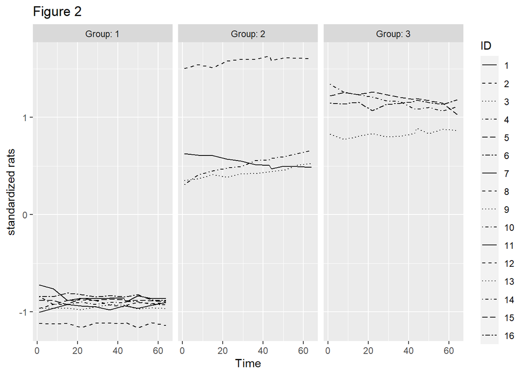

```r
# Plot again with the standardised bprs
ggplot(ratsl, aes(x = Time, y = stdrats, linetype = ID)) +
  geom_line() +
  scale_linetype_manual(values = rep(1:10, times=4)) +
  facet_grid(. ~ Group, labeller = label_both) +
  scale_y_continuous(name = "standardized rats") + ggtitle("Figure 2")
```

After having standardized the variable rats, the figures look quite different. Comparing Figure 1 and Figure 2, first thing to notice is the change in the slopes to the opposite, which seams a bit strange. It still looks like all groups have possible outlier with Group 2 having a clear outlier.

```r
# Number of time periods, baseline (time 0) included
n <- ratsl$Time %>% unique() %>% length()


# Summary data with mean and standard error of rats by Group and Time
ratsls <- ratsl %>%
  group_by(Group, Time) %>%
  summarise( mean = mean(rats), se = sd(rats)/sqrt(n) ) %>%
  ungroup()
# Glimpse the data
glimpse(ratsls)
```

```
## Rows: 33
## Columns: 4
## $ Group <fct> 1, 1, 1, 1, 1, 1, 1, 1, 1, 1, 1, 2, 2, 2, 2, 2, 2, 2, 2, 2, 2...
## $ Time  <int> 1, 8, 15, 22, 29, 36, 43, 44, 50, 57, 64, 1, 8, 15, 22, 29, 3...
## $ mean  <dbl> 250.625, 255.000, 254.375, 261.875, 264.625, 265.000, 267.375...
## $ se    <dbl> 4.589478, 3.947710, 3.460116, 4.100800, 3.333956, 3.552939, 3...
```

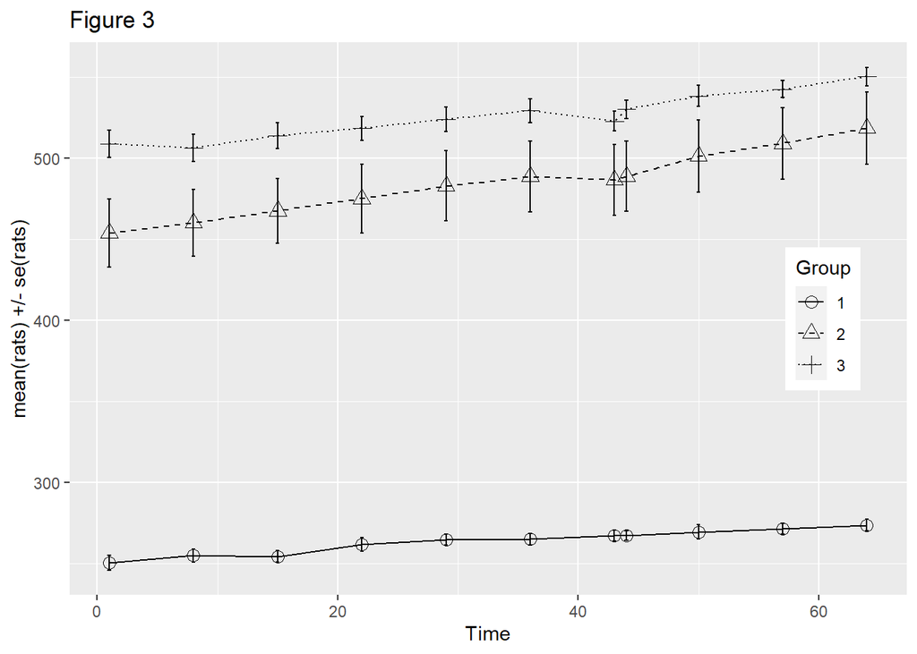

```r
# Plot the mean profiles
ggplot(ratsls, aes(x = Time, y = mean, linetype = Group, shape = Group)) +
  geom_line() +
  scale_linetype_manual(values = c(1,2,3)) +
  geom_point(size=3) +
  scale_shape_manual(values = c(1,2,3)) +
  geom_errorbar(aes(ymin = mean - se, ymax = mean + se, linetype="1"), width=0.3) +
  theme(legend.position = c(0.9,0.5)) +
  scale_y_continuous(name = "mean(rats) +/- se(rats)") + ggtitle("Figure 3")
```

```r
# Create a summary data by treatment and subject with mean as the summary variable (ignoring baseline week 0).
rats8l <- ratsl %>%
  filter(Time > 0) %>%
  group_by(Group, ID) %>%
  summarise( mean=mean(rats) ) %>%
  ungroup()
# Glimpse the data
glimpse(rats8l)
```

```
## Rows: 16
## Columns: 3
## $ Group <fct> 1, 1, 1, 1, 1, 1, 1, 1, 2, 2, 2, 2, 3, 3, 3, 3
## $ ID    <fct> 1, 2, 3, 4, 5, 6, 7, 8, 9, 10, 11, 12, 13, 14, 15, 16
## $ mean  <dbl> 261.0909, 237.6364, 260.1818, 266.5455, 269.4545, 274.7273, 2...
```

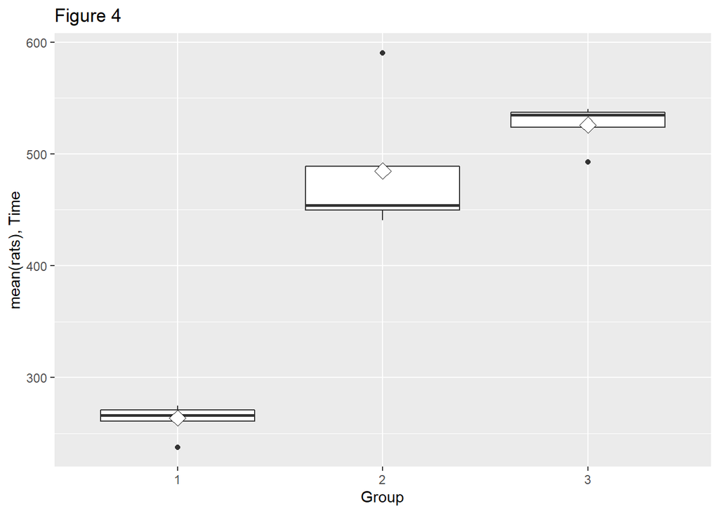

```r
# Draw a boxplot of the mean versus treatment
ggplot(rats8l, aes(x = Group, y = mean)) +
  geom_boxplot() +
  stat_summary(fun.y = "mean", geom = "point", shape=23, size=4, fill = "white") +
  scale_y_continuous(name = "mean(rats), Time") + ggtitle("Figure 4")
```

```r
# Create a new data by filtering the outlier and adjust the ggplot code the draw the plot again with the new data
rats8l1 <- rats8l %>%
  filter(mean < 60)
```

```r
# Perform a three-sample f-test?
# t.test(mean ~ Group, data = rats8l1, var.equal = TRUE)

# Add the baseline from the original data as a new variable to the summary data
rats8l2 <- rats8l %>%
  mutate(baseline = rats$WD1)

# Fit the linear model with the mean as the response
fit <- lm(mean ~ baseline + Group, data = rats8l2)


# Compute the analysis of variance table for the fitted model with anova()
anova(fit)
```

```
## Analysis of Variance Table
##
## Response: mean
##           Df Sum Sq Mean Sq   F value    Pr(>F)
## baseline   1 252125  252125 2237.0655 5.217e-15 ***
## Group      2    726     363    3.2219   0.07586 .
## Residuals 12   1352     113
## ---
## Signif. codes:  0 '***' 0.001 '**' 0.01 '*' 0.05 '.' 0.1 ' ' 1
```

```r
?f.test
```

```
## No documentation for 'f.test' in specified packages and libraries:
## you could try '??f.test'
```

## Part 2.

On the BPRS data based on Kimmo’s book:

Here 40 male subjects were randomly assigned to one of two treatment groups and each subject was rated on the brief psychiatric rating scale (BPRS) measured before treatment began (week 0) and then at weekly intervals for eight weeks. The BPRS assesses the level of 18 symptom constructs such as hostility, suspiciousness, hallucinations and grandiosity; each of these is rated from one (not present) to seven (extremely severe). The scale is used to evaluate patients suspected of having schizophrenia.

```r
rm(list=ls())

# Data
BPRS <- read.table("https://raw.githubusercontent.com/KimmoVehkalahti/MABS/master/Examples/data/BPRS.txt",
                   sep ="" , header = TRUE)

BPRSL <- read.table( "Z:/FDPE/Courses/Datamooc/IODS-project/data/BPRSL.txt", sep = " ", header = TRUE)



names(BPRSL)
```

```
## [1] "treatment" "subject"   "weeks"     "bprs"      "week"
```

```r
#Access the package ggplot2
library(ggplot2)
library(tidyr)
library(dplyr)

BPRSL$subject <- as.factor(BPRSL$subject)
BPRSL$treatment <- as.factor(BPRSL$treatment)


dim(BPRSL)
```

```
## [1] 360   5
```

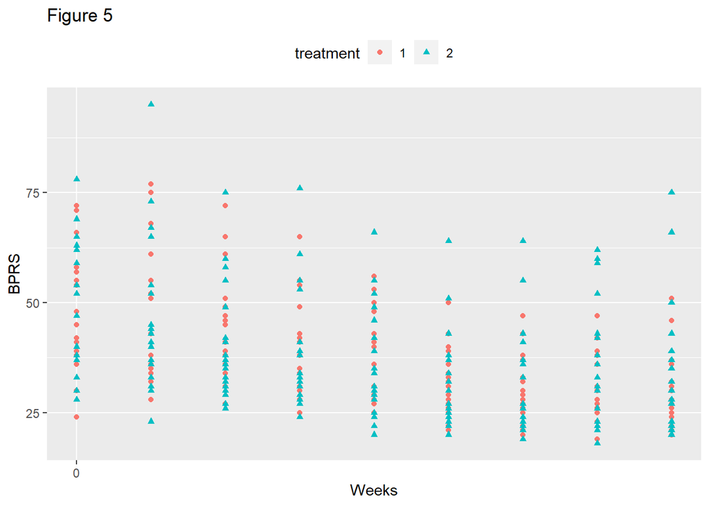

```r
# Plot the BPRSL data
ggplot(BPRSL, aes(x = week, y = bprs, group = subject)) +
  geom_point(aes(linetype = treatment, shape = treatment, color = treatment)) +
  scale_x_continuous(name = "Weeks", breaks = seq(0, 60, 10)) +
  scale_y_continuous(name = "BPRS") +
  theme(legend.position = "top") +
  ggtitle("Figure 5")
```

Figure 5 plots the bprs-scores for the two treatment groups. It appears that for both groups, the scores decrease over the weeks. Looking at the lowest and highest scores for each week, it appears that variance is higher for group 2, although it is difficult so see any clear indication of which treatment performs better on average.

```r
# create a regression model bprs_reg
fit <- lm(bprs ~ weeks + treatment, data = BPRSL)

# print out a summary of the model
summary(fit)
```

```
##
## Call:
## lm(formula = bprs ~ weeks + treatment, data = BPRSL)
##
## Residuals:
##     Min      1Q  Median      3Q     Max
## -23.714  -9.226  -2.989   6.786  48.389
##
## Coefficients:
##             Estimate Std. Error t value Pr(>|t|)
## (Intercept)  47.7139     2.0590  23.173  < 2e-16 ***
## weeksweek1   -1.6750     2.7624  -0.606  0.54467
## weeksweek2   -6.3000     2.7624  -2.281  0.02317 *
## weeksweek3   -8.8500     2.7624  -3.204  0.00148 **
## weeksweek4  -11.6500     2.7624  -4.217 3.15e-05 ***
## weeksweek5  -15.4500     2.7624  -5.593 4.51e-08 ***
## weeksweek6  -16.7750     2.7624  -6.073 3.28e-09 ***
## weeksweek7  -15.8000     2.7624  -5.720 2.29e-08 ***
## weeksweek8  -16.5750     2.7624  -6.000 4.92e-09 ***
## treatment2    0.5722     1.3022   0.439  0.66063
## ---
## Signif. codes:  0 '***' 0.001 '**' 0.01 '*' 0.05 '.' 0.1 ' ' 1
##
## Residual standard error: 12.35 on 350 degrees of freedom
## Multiple R-squared:  0.2026, Adjusted R-squared:  0.182
## F-statistic: 9.878 on 9 and 350 DF,  p-value: 1.62e-13
```

```r
# access library lme4
library(lme4)
# Create a random intercept model
bprs_ref <- lmer(bprs ~ weeks + treatment + (1 | subject), data = BPRSL, REML = FALSE)

# Print the summary of the model
summary(bprs_ref)
```

```
## Linear mixed model fit by maximum likelihood  ['lmerMod']
## Formula: bprs ~ weeks + treatment + (1 | subject)
##    Data: BPRSL
##
##      AIC      BIC   logLik deviance df.resid
##   2751.3   2798.0  -1363.7   2727.3      348
##
## Scaled residuals:
##     Min      1Q  Median      3Q     Max
## -3.2309 -0.6213 -0.1018  0.4877  3.3537
##
## Random effects:
##  Groups   Name        Variance Std.Dev.
##  subject  (Intercept)  47.6     6.899
##  Residual             100.8    10.039
## Number of obs: 360, groups:  subject, 20
##
## Fixed effects:
##             Estimate Std. Error t value
## (Intercept)  47.7139     2.2758  20.965
## weeksweek1   -1.6750     2.2448  -0.746
## weeksweek2   -6.3000     2.2448  -2.807
## weeksweek3   -8.8500     2.2448  -3.942
## weeksweek4  -11.6500     2.2448  -5.190
## weeksweek5  -15.4500     2.2448  -6.883
## weeksweek6  -16.7750     2.2448  -7.473
## weeksweek7  -15.8000     2.2448  -7.039
## weeksweek8  -16.5750     2.2448  -7.384
## treatment2    0.5722     1.0582   0.541
##
## Correlation of Fixed Effects:
##            (Intr) wkswk1 wkswk2 wkswk3 wkswk4 wkswk5 wkswk6 wkswk7 wkswk8
## weeksweek1 -0.493
## weeksweek2 -0.493  0.500
## weeksweek3 -0.493  0.500  0.500
## weeksweek4 -0.493  0.500  0.500  0.500
## weeksweek5 -0.493  0.500  0.500  0.500  0.500
## weeksweek6 -0.493  0.500  0.500  0.500  0.500  0.500
## weeksweek7 -0.493  0.500  0.500  0.500  0.500  0.500  0.500
## weeksweek8 -0.493  0.500  0.500  0.500  0.500  0.500  0.500  0.500
## treatment2 -0.232  0.000  0.000  0.000  0.000  0.000  0.000  0.000  0.000
```

Models

```r
# create a random intercept and random slope model
bprs_ref1 <- lmer(bprs ~ weeks + treatment+ (weeks | subject), data = BPRSL, REML = FALSE)
```

```
## boundary (singular) fit: see ?isSingular
```

```r
# print a summary of the model
summary(bprs_ref1)
```

```
## Linear mixed model fit by maximum likelihood  ['lmerMod']
## Formula: bprs ~ weeks + treatment + (weeks | subject)
##    Data: BPRSL
##
##      AIC      BIC   logLik deviance df.resid
##   2825.5   3043.1  -1356.7   2713.5      304
##
## Scaled residuals:
##     Min      1Q  Median      3Q     Max
## -3.0212 -0.5626 -0.0752  0.5371  3.3227
##
## Random effects:
##  Groups   Name        Variance Std.Dev. Corr
##  subject  (Intercept) 51.940   7.207
##           weeksweek1  11.027   3.321     0.33
##           weeksweek2   8.807   2.968     0.09  0.68
##           weeksweek3  15.513   3.939     0.00  0.92  0.83
##           weeksweek4  24.521   4.952    -0.45  0.66  0.37  0.78
##           weeksweek5  30.318   5.506    -0.58  0.47  0.12  0.58  0.96
##           weeksweek6  43.572   6.601    -0.53  0.48  0.08  0.57  0.96  1.00
##           weeksweek7  49.964   7.069    -0.41  0.57  0.09  0.61  0.95  0.98
##           weeksweek8  51.948   7.207    -0.33  0.64  0.15  0.66  0.96  0.96
##  Residual             90.733   9.525
##
##
##
##
##
##
##
##
##   0.99
##   0.98  1.00
##
## Number of obs: 360, groups:  subject, 20
##
## Fixed effects:
##             Estimate Std. Error t value
## (Intercept)  47.7139     2.2622  21.092
## weeksweek1   -1.6750     2.2557  -0.743
## weeksweek2   -6.3000     2.2309  -2.824
## weeksweek3   -8.8500     2.3048  -3.840
## weeksweek4  -11.6500     2.4006  -4.853
## weeksweek5  -15.4500     2.4602  -6.280
## weeksweek6  -16.7750     2.5914  -6.473
## weeksweek7  -15.8000     2.6523  -5.957
## weeksweek8  -16.5750     2.6710  -6.206
## treatment2    0.5722     1.0041   0.570
##
## Correlation of Fixed Effects:
##            (Intr) wkswk1 wkswk2 wkswk3 wkswk4 wkswk5 wkswk6 wkswk7 wkswk8
## weeksweek1 -0.367
## weeksweek2 -0.430  0.517
## weeksweek3 -0.434  0.552  0.535
## weeksweek4 -0.566  0.519  0.474  0.548
## weeksweek5 -0.613  0.485  0.431  0.512  0.606
## weeksweek6 -0.601  0.479  0.406  0.505  0.616  0.640
## weeksweek7 -0.551  0.490  0.400  0.510  0.618  0.640  0.666
## weeksweek8 -0.518  0.504  0.407  0.522  0.620  0.636  0.663  0.678
## treatment2 -0.222  0.000  0.000  0.000  0.000  0.000  0.000  0.000  0.000
## optimizer (nloptwrap) convergence code: 0 (OK)
## boundary (singular) fit: see ?isSingular
```

```r
# perform an ANOVA test on the two models
anova(bprs_ref1, bprs_ref)
```

```
## Data: BPRSL
## Models:
## bprs_ref: bprs ~ weeks + treatment + (1 | subject)
## bprs_ref1: bprs ~ weeks + treatment + (weeks | subject)
##           npar    AIC    BIC  logLik deviance  Chisq Df Pr(>Chisq)
## bprs_ref    12 2751.3 2798.0 -1363.7   2727.3
## bprs_ref1   56 2825.5 3043.1 -1356.7   2713.5 13.837 44          1
```

```r
# create a random intercept and random slope model
bprs_ref2 <- lmer(bprs ~ weeks * treatment + (weeks | subject), data = BPRSL, REML = FALSE)
```

```
## boundary (singular) fit: see ?isSingular
```

```r
# print a summary of the model
summary(bprs_ref2)
```

```
## Linear mixed model fit by maximum likelihood  ['lmerMod']
## Formula: bprs ~ weeks * treatment + (weeks | subject)
##    Data: BPRSL
##
##      AIC      BIC   logLik deviance df.resid
##   2832.7   3081.4  -1352.3   2704.7      296
##
## Scaled residuals:
##     Min      1Q  Median      3Q     Max
## -3.1485 -0.5778 -0.0825  0.5463  3.4517
##
## Random effects:
##  Groups   Name        Variance Std.Dev. Corr
##  subject  (Intercept) 53.16    7.291
##           weeksweek1  11.76    3.429     0.29
##           weeksweek2  10.47    3.235     0.04  0.70
##           weeksweek3  17.69    4.206    -0.04  0.92  0.85
##           weeksweek4  26.32    5.130    -0.47  0.68  0.42  0.79
##           weeksweek5  31.56    5.618    -0.59  0.48  0.16  0.59  0.96
##           weeksweek6  45.07    6.713    -0.54  0.50  0.12  0.58  0.95  1.00
##           weeksweek7  51.52    7.178    -0.42  0.57  0.12  0.61  0.95  0.98
##           weeksweek8  53.68    7.327    -0.35  0.65  0.18  0.66  0.95  0.96
##  Residual             88.10    9.386
##
##
##
##
##
##
##
##
##   0.99
##   0.98  1.00
##
## Number of obs: 360, groups:  subject, 20
##
## Fixed effects:
##                       Estimate Std. Error t value
## (Intercept)             47.000      2.658  17.685
## weeksweek1              -0.200      3.066  -0.065
## weeksweek2              -3.450      3.055  -1.129
## weeksweek3              -6.100      3.114  -1.959
## weeksweek4             -10.400      3.182  -3.268
## weeksweek5             -14.300      3.223  -4.437
## weeksweek6             -17.300      3.326  -5.201
## weeksweek7             -17.200      3.374  -5.097
## weeksweek8             -17.700      3.390  -5.221
## treatment2               2.000      2.968   0.674
## weeksweek1:treatment2   -2.950      4.198  -0.703
## weeksweek2:treatment2   -5.700      4.198  -1.358
## weeksweek3:treatment2   -5.500      4.198  -1.310
## weeksweek4:treatment2   -2.500      4.198  -0.596
## weeksweek5:treatment2   -2.300      4.198  -0.548
## weeksweek6:treatment2    1.050      4.198   0.250
## weeksweek7:treatment2    2.800      4.198   0.667
## weeksweek8:treatment2    2.250      4.198   0.536
```

```
##
## Correlation matrix not shown by default, as p = 18 > 12.
## Use print(x, correlation=TRUE)  or
##     vcov(x)        if you need it
```

```
## optimizer (nloptwrap) convergence code: 0 (OK)
## boundary (singular) fit: see ?isSingular
```

```r
# perform an ANOVA test on the two models
anova(bprs_ref2, bprs_ref1)
```

```
## Data: BPRSL
## Models:
## bprs_ref1: bprs ~ weeks + treatment + (weeks | subject)
## bprs_ref2: bprs ~ weeks * treatment + (weeks | subject)
##           npar    AIC    BIC  logLik deviance  Chisq Df Pr(>Chisq)
## bprs_ref1   56 2825.5 3043.1 -1356.7   2713.5
## bprs_ref2   64 2832.7 3081.4 -1352.3   2704.7 8.7955  8     0.3598
```

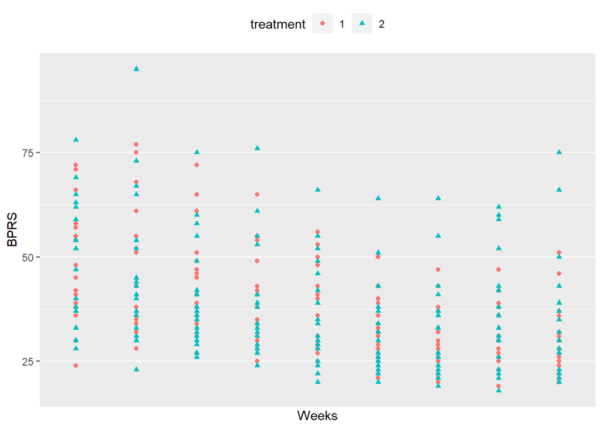

```r
# draw the plot of RATSL
ggplot(BPRSL, aes(x = weeks, y = bprs, group = subject)) +
  geom_point(aes(linetype = treatment, shape = treatment, color = treatment)) +
  scale_x_discrete(name = "Weeks", breaks = seq(0, 60, 20)) +
  scale_y_continuous(name = "BPRS") +
  theme(legend.position = "top")
```

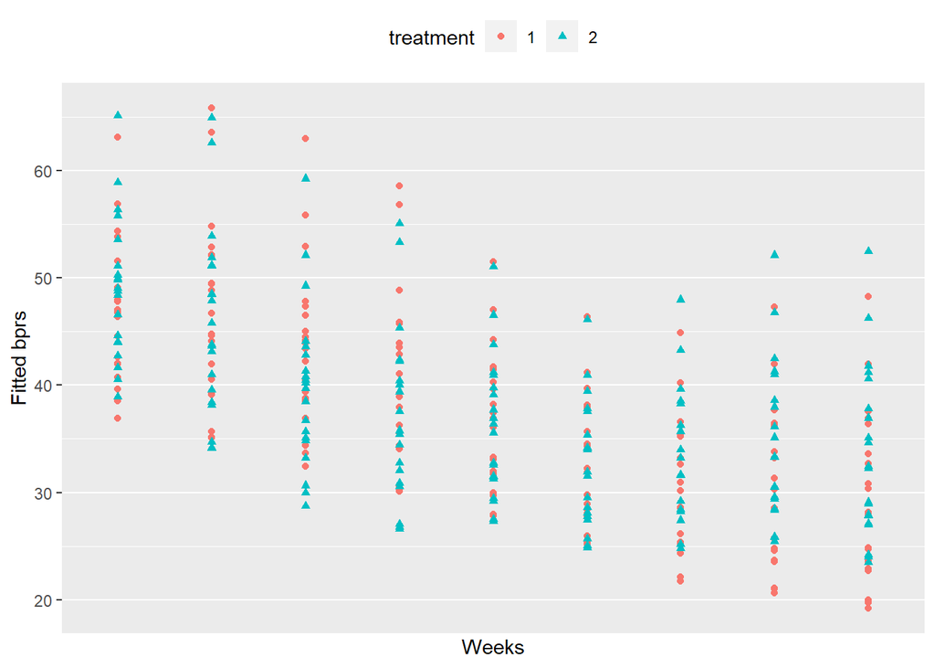

```r
# Create a vector of the fitted values
Fitted <- fitted(bprs_ref2)

# Create a new column fitted to RATSL
BPRSL <- BPRSL %>%
  mutate(Fitted)

# draw the plot of RATSL
ggplot(BPRSL, aes(x = weeks, y = Fitted, group = subject)) +
  geom_point(aes(linetype = treatment, shape = treatment, color = treatment)) +
  scale_x_discrete(name = "Weeks", breaks = seq(0, 60, 20)) +
  scale_y_continuous(name = "Fitted bprs") +
  theme(legend.position = "top")
```